# Analiza

Patrycja Piła

2023-04-15

# Wprowadzanie zmiennych

## HDI

#### Zmienna `hdi` oznacza wskaźnik HDI, czyli syntetyczny miernik opisujący stopień rozwoju społeczno-ekonomicznego poszczególnych krajów.

## Długość życia

#### Zmienna `lifExp` oznacza średnią liczbę lat, które przeżyłoby nowo narodzone dziecko, gdyby obecne wzorce umieralności pozostały takie same.

## Śmiertelność dzieci

#### Zmienna `children` oznacza ile dzieci w wieku od 0 do 5 lat umiera w przeliczeniu na 1000 urodzeń.

## PKB per capita

#### Zmienna `income` oznacza Produkt Krajowy Brutto na osobę skorygowany o różnice w sile nabywczej (w dolarach międzynarodowych, ceny stałe z 2017 r., PPP na podstawie ICP z 2017 r.).

## Przemysł

#### Zmienna `industry` oznacza procentowy udział przemysłu w tworzeniu PKB.

## Rolnictwo

#### Zmienna `agriculture` oznacza procentowy udział rolnictwa w PKB.

## Usługi

#### Zmienna `services` oznacza procentowy udział usługach w PKB.

## Urbanizacja

#### Zmienna `urban` odnosi się do osób mieszkających na obszarach miejskich określonych przez krajowe urzędy statystyczne wyrażone procentowo do ogólnej liczby ludności.

# Łączenie zmiennych w jedną tabelę.

```
## # A tibble: 6 × 11
##   country     year  urban lifExp   hdi children industry income agricu…¹ servi…²
##   <chr>       <chr> <dbl>  <dbl> <dbl>    <dbl>    <dbl>  <dbl>    <dbl>   <dbl>
## 1 Afghanistan 1991   21.3   53.8 0.307      173    12.4    1020     63.4    24.1
## 2 Afghanistan 1993   21.4   54.4 0.312      161    11.6     672     64.4    24
## 3 Afghanistan 1995   21.6   54.3 0.331      151    11.5     736     64.3    24.2
## 4 Afghanistan 1997   21.8   54.5 0.339      142    10.7     663     65      24.3
## 5 Afghanistan 1999   22     54.7 0.348      133     9.95    603     65.5    24.6
## 6 Afghanistan 2001   22.2   54.8 0.353      125     8.98    569     66.3    24.7
## # … with 1 more variable: continent <fct>, and abbreviated variable names
## #   ¹agriculture, ²services
```

# **1. Czy PKB per capita ma wpływ na śmiertelność dzieci?**

#### Według mnie tak. Przyjrzyjmy się jak wygląda wykres przedstawiający te dwie zmienne.

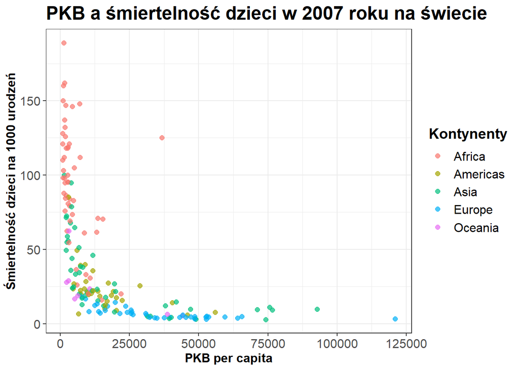

```r
dane %>%
  filter(year == 2007) %>%
  ggplot() +
  geom_point(mapping = aes(x = income,
                           y = children,
                           col = continent),
             size = 2,
             alpha = 0.7) +
  labs(
    title = "PKB a śmiertelność dzieci w 2007 roku na świecie",
    x = "PKB per capita",
    y = "Śmiertelność dzieci na 1000 urodzeń",
    color = "Kontynenty"
  ) +
  theme_bw() +
  theme(
    axis.text = element_text(size = 12),
    axis.title = element_text(size = 12,
                              face = "bold"),
    plot.title = element_text(size = 18,
                              face = "bold"),
    legend.title = element_text(size = 14,
                                face = "bold"),
    legend.text = element_text(size = 12)
  )
```

#### Dane na wykresie nie mają zależności liniowej. Żeby sprawdzić występujące zależności wykorzystam współczynnik korelacji, ponieważ nie ogranicza się on tylko do zależności liniowej.

```r
cor(dane$income,dane$children,method = 'spearman')
```

```
## [1] -0.8790068
```

#### Jak można łatwo zauważyć występują dane o zróżnicowanych wartościach, lecz są one malejące. Dlatego sprawdźmy, jak wygląda wykres na podstawie tych samych danych ale przedstawiony na skali logarytmicznej.

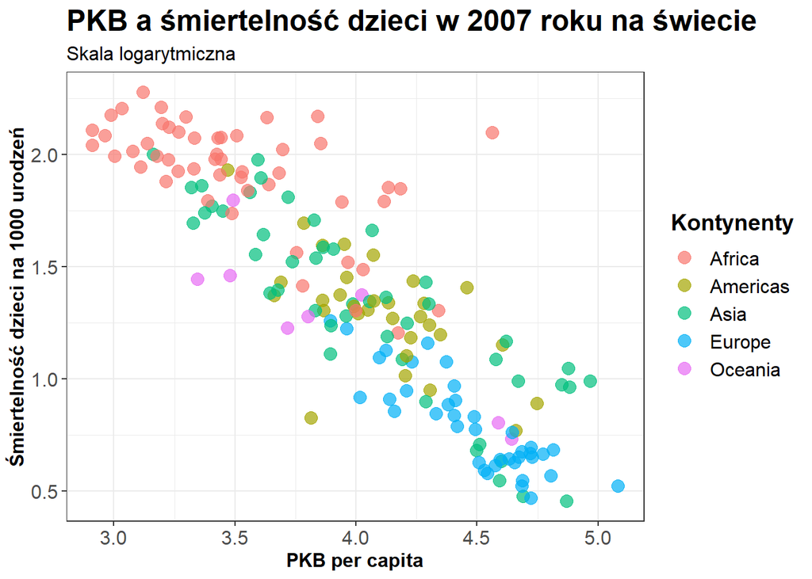

```r
dane %>%
  filter(year == 2007) %>%
  select(country, year, income, continent, children) %>%
  ggplot() +
  geom_point(mapping = aes(
    x = log10(income),
    y = log10(children),
    col = continent
  ),
  size = 3.5,
  alpha = 0.7) +
  labs(
    title = "PKB a śmiertelność dzieci w 2007 roku na świecie",
    subtitle = "Skala logarytmiczna",
    x = "PKB per capita",
    y = "Śmiertelność dzieci na 1000 urodzeń",
    color = "Kontynenty"
  ) +
  theme_bw() +
  theme(
    axis.text = element_text(size = 12),
    axis.title = element_text(size = 12,
                              face = "bold"),
    plot.title = element_text(size = 18,
                              face = "bold"),
    plot.subtitle =element_text(size = 12),
    legend.title = element_text(size = 14,
                                face = "bold"),
    legend.text = element_text(size = 12)
  )
```

#### W tym momencie dużo lepiej widać zależność między tymi danymi. Wraz z wzrostem PKB per capita spada liczba śmierci na 1000 urodzeń.

#### Dla pewności sprawdźmy jeszcze ile wynosi współczynnik korelacji.

```r
cor(log10(dane$income), log10(dane$children))
```

```
## [1] -0.8749134
```

#### Między tymi danymi występuje silna korelacja. Można więc powiedzieć, że są to zmienne odwrotnie proporcjonalne, co potwierdza moją początkową hipotezę.

# **2. Czy państwa posiadające niższe PKB w większości specjalizują się w rolnictwie?**

#### Na samym początku przyjrzyjmy się jak wygląda średni poziom udziału rolnictwa w PKB na przestrzeni lat z podziałem na kontynenty.

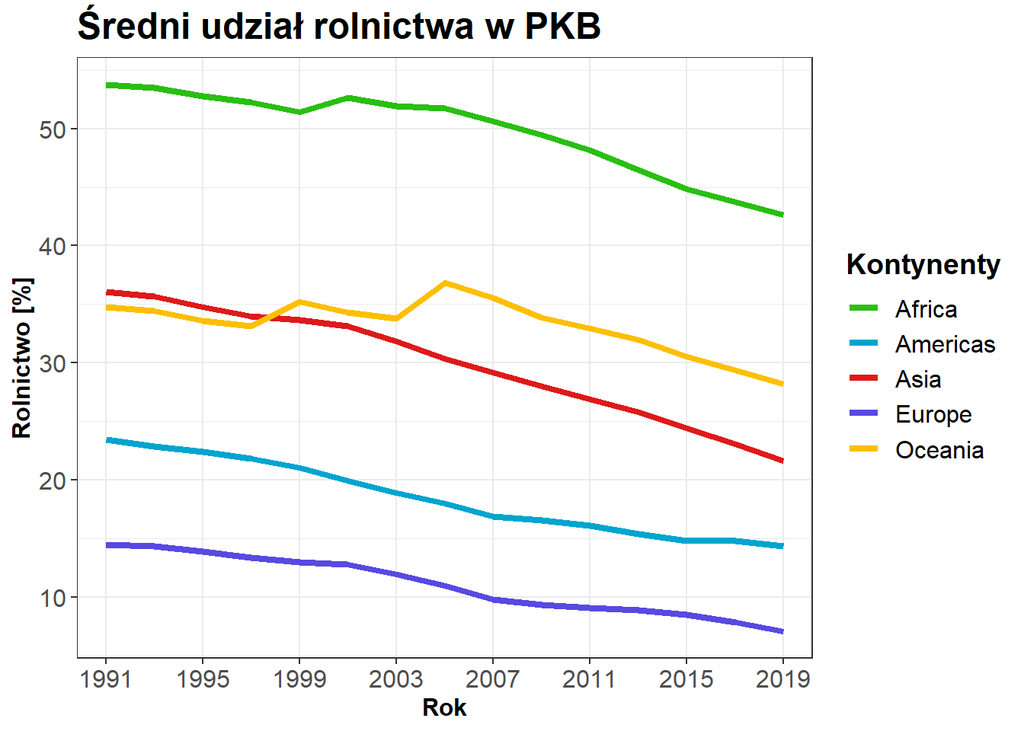

```r
dane %>%
  select(country, year, continent, agriculture) %>%
  group_by(continent, year) %>%
  mutate(agri = mean(agriculture)) %>%
  ggplot(mapping = aes(
    x = year,
    y = agri,
    col = continent,
    group = continent
  )) +
  geom_line(size = 1.5) +
  scale_x_discrete(breaks = seq(1991, 2019, 4)) +
  labs(
    title = "Średni udział rolnictwa w PKB",
    x = "Rok",
    y = "Rolnictwo [%]",
    color = "Kontynenty"
  ) +
  theme_bw() +
  scale_color_jcolors() +
  theme_bw() +
  theme(
    axis.text = element_text(size = 12),
    axis.title = element_text(size = 12,
                              face = "bold"),
    plot.title = element_text(size = 18,
                              face = "bold"),
    legend.title = element_text(size = 14,
                                face = "bold"),
    legend.text = element_text(size = 12)
  )
```

#### Ewidentnie widać, że w państwach afrykańskich udział rolnictwa jest zdecydowanie większy. Sprawdźmy więc jak wygląda kwestia PKB per capita.

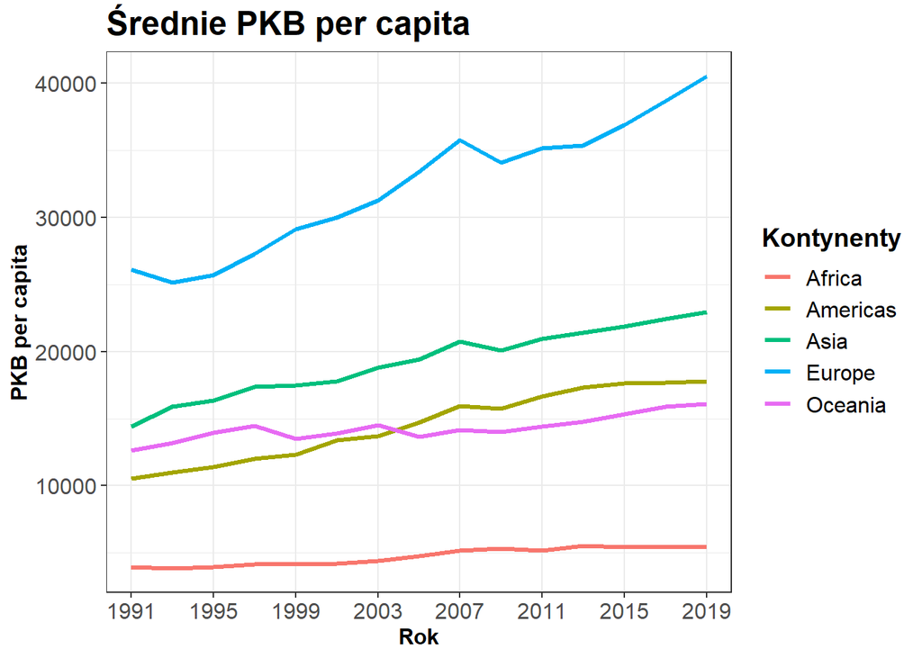

```r
dane %>%
  select(country, year, continent, income) %>%
  group_by(continent, year) %>%
  summarise(inc = mean(income)) %>%
  ggplot(aes(
    x = year,
    y = inc,
    col = continent,
    group = continent
  )) +
  geom_line(size = 1.2) +
  scale_x_discrete(breaks = seq(1991, 2019, 4)) +
  labs(
    title = "Średnie PKB per capita",
    x = "Rok",
    y = "PKB per capita",
    color = "Kontynenty"
  ) +
  theme_bw() +
  theme(
    axis.text = element_text(size = 12),
    axis.title = element_text(size = 12,
                              face = "bold"),
    plot.title = element_text(size = 18,
                              face = "bold"),
    legend.title = element_text(size = 14,
                                face = "bold"),
    legend.text = element_text(size = 12)
  )
```

#### Kraje afrykańskie zdecydowanie odbiegają w jego poziomie w porównaniu do reszty świata.

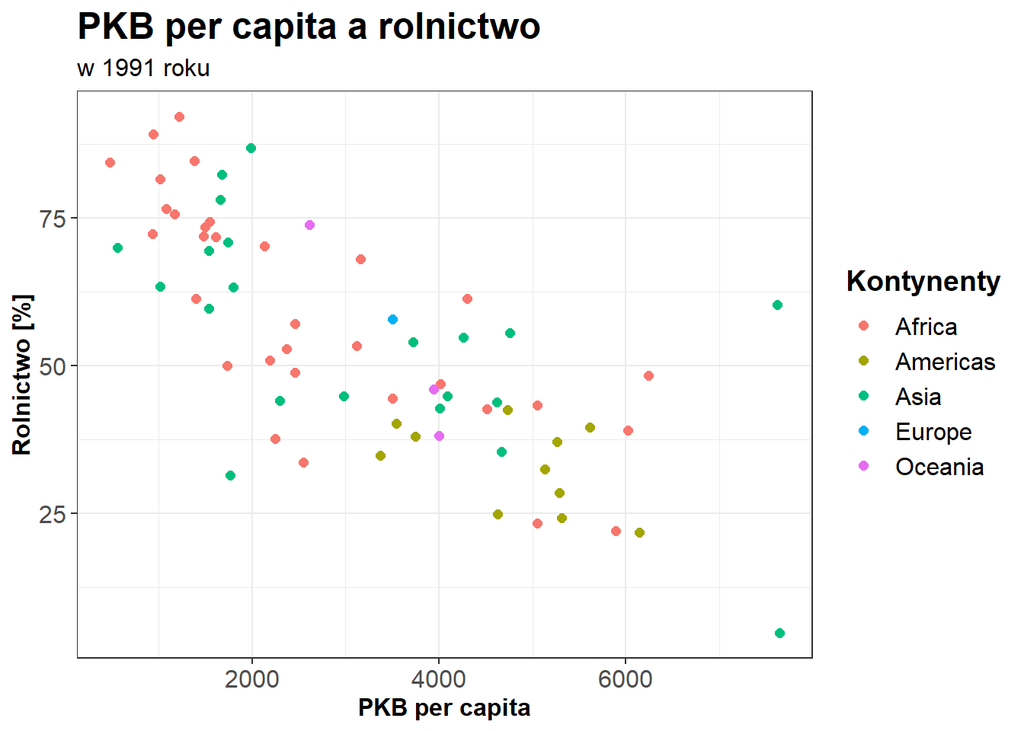

```r
dane %>%
  filter(year == "1991", income < 8000) %>%
  group_by(continent) %>%
  ggplot() +
  geom_point(mapping = aes(x = income,
                           y = agriculture,
                           col = continent),
             size = 2) +
  labs(
    title = "PKB per capita a rolnictwo",
    subtitle = "w 1991 roku",
    x = "PKB per capita",
    y = "Rolnictwo [%]",
    color = "Kontynenty"
  ) +
  theme_bw() +
  theme(
    axis.text = element_text(size = 12),
    axis.title = element_text(size = 12,
                              face = "bold"),
    plot.title = element_text(size = 18,
                              face = "bold"),
    plot.subtitle =element_text(size = 12),
    legend.title = element_text(size = 14,
                                face = "bold"),
    legend.text = element_text(size = 12)
  )
```

#### Na powyższym wykresie przedstawione zostały dwie dane: procentowy udział rolnictwa w PKB oraz PKB per capita w danym państwie.

[figure not shown]

```r
count(dane %>%
  filter(year == "1991", income < 8000))
```

```
## # A tibble: 1 × 1
##       n
##   <int>
## 1    68
```

```r
count(dane %>%
  filter(year == "1991", income < 8000,agriculture >=50))
```

```
## # A tibble: 1 × 1
##       n
##   <int>
## 1    36
```

#### Natomiast tych w, których dodatkowo udział rolnictwa w PKB wynosi powyżej 50 % jest 36.

#### Zatem jest to ponad połowa wszystkich państw.

#### W Afryce państw o niskim PKB per capita znajduje się (lata 1991/1995):

```
## # A tibble: 1 × 1
##       n
##   <int>
## 1    32
```

```
## # A tibble: 1 × 1
##       n
##   <int>
## 1    34
```

#### W Azji państw o niskim PKB per capita znajduje się (lata 1991/1995):

```
## # A tibble: 1 × 1
##       n
##   <int>
## 1    21
```

```
## # A tibble: 1 × 1
##       n
##   <int>
## 1    20
```

#### W Amerykach państw o niskim PKB per capita znajduje się (lata 1991/1995):

```
## # A tibble: 1 × 1
##       n
##   <int>
## 1    11
```

```
## # A tibble: 1 × 1
##       n
##   <int>
## 1    11
```

#### W Europie państw o niskim PKB per capita znajduje się (lata 1991/1995):

```
## # A tibble: 1 × 1
##       n
##   <int>
## 1     1
```

```
## # A tibble: 1 × 1
##       n
##   <int>
## 1     5
```

#### Najwięcej państw z niskim PKB znajduje się na kontynencie afrykańskim. Co samo w sobie nie jest zaskoczeniem. Dosyć ciekawą rzeczą dla mnie jest pojawienie się większej liczby państw europejskich o niższym poziomie PKB w ciągu zaledwie 4 lat. Tym jednak zajmę się już w następnym pytaniu.

#### Wiemy już że Afryka przoduje w państwach zarówno o dużym udziale rolnictwa w PKB, jak i tych o niskim PKB per capita. Zatem wróćmy do pierwotnego pytania.

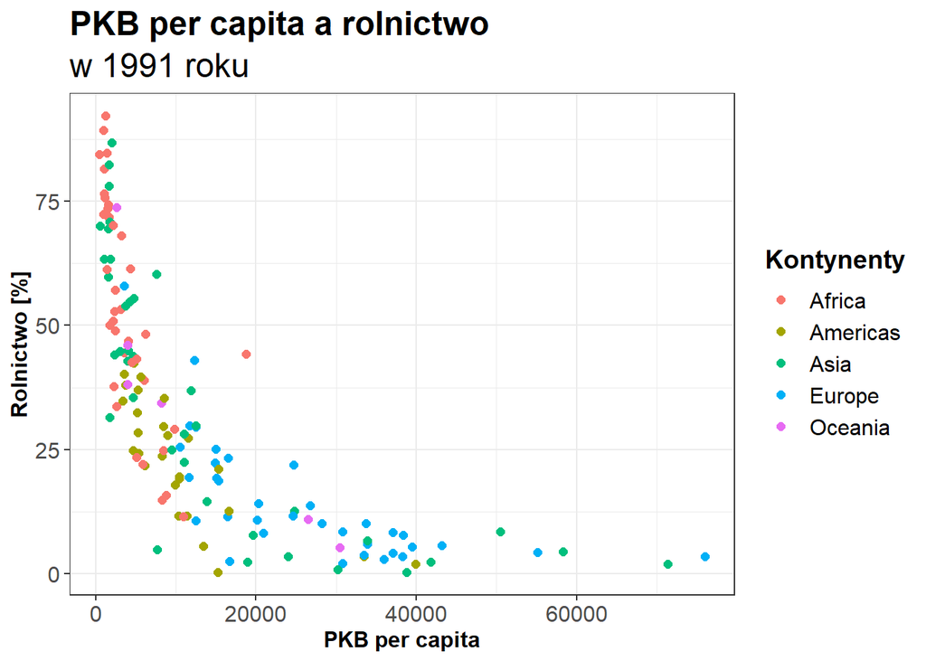

```r
dane %>%
  filter(year == 1991) %>%
  ggplot() +
  geom_point(mapping = aes(x = income,
                           y = agriculture,
                           col = continent),
             size = 2) +
  labs(
    title = "PKB per capita a rolnictwo",
    subtitle = "w 1991 roku",
    x = "PKB per capita",
    y = "Rolnictwo [%]",
    color = "Kontynenty"
  ) +
  theme_bw() +
  theme(
    axis.text = element_text(size = 12),
    axis.title = element_text(size = 12,
                              face = "bold"),
    plot.title = element_text(size = 18,
                              face = "bold"),
    plot.subtitle = element_text(size = 18),
    legend.title = element_text(size = 14,
                                face = "bold"),
    legend.text = element_text(size = 12)
  )
```

```r
cor(dane$income,dane$agriculture,method = "spearman")
```

```
## [1] -0.9109213
```

#### Zarówno kształt wykresu jak i współczynnik korelacji spearmana obrazują, iż PKB per capita ma wpływ na procentowy udział rolnictwa w gospodarce.

```r
roln<- dane%>%
  select(country,year,continent,agriculture,income)%>%
  filter(income <5000,year ==1991)

roln
```

```
## # A tibble: 55 × 5
##    country                  year  continent agriculture income
##    <chr>                    <chr> <fct>           <dbl>  <dbl>
##  1 Afghanistan              1991  Asia             63.4   1020
##  2 Albania                  1991  Europe           57.9   3500
##  3 Armenia                  1991  Asia             43.8   4620
##  4 Burundi                  1991  Africa           92.1   1220
##  5 Benin                    1991  Africa           50.9   2190
##  6 Bangladesh               1991  Asia             69.5   1540
##  7 Bolivia                  1991  Americas         42.5   4730
##  8 Central African Republic 1991  Africa           75.7   1170
##  9 China                    1991  Asia             59.7   1540
## 10 Cote d'Ivoire            1991  Africa           52.8   2370
## # … with 45 more rows
```

```r
mean(roln$agriculture)
```

```
## [1] 58.52909
```

#### Jak widać średni procentowy udział sektora rolnictwa w gospodarce wynosi ponad 58% więc można stwierdzić, że państwa posiadające niższe PKB per capita w większości specjalizują się w rolnictwie.

#### Biorąc to wszystko pod uwagę mogę stwierdzić, że **państwa posiadające niższe PKB w większości specjalizują się w rolnictwie**

# **3. Jak wyglądała struktura gospodarki w krajach europejskich z niskim PKB per capita?**

#### Próbując odpowiedzieć na poprzednie pytanie natknęłam się na dość ciekawą informację o tym, że w Europie zwiększyła się w ciągu 4 lat liczba państw o niskim PKB per capita.

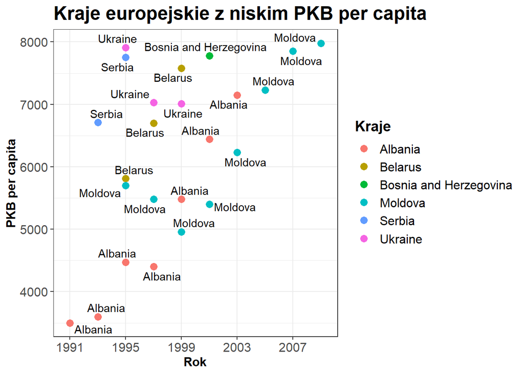

```r
dane %>%
  filter(income < 8000, continent == "Europe") %>%
  ggplot(aes(year, income, col = country)) +
  geom_point(size = 3) +
  geom_text_repel(aes(label = country), color = "black") +
  labs(
    title = "Kraje europejskie z niskim PKB per capita",
    x = "Rok",
    y = "PKB per capita",
    color = "Kraje"
  ) +
  scale_x_discrete(breaks = seq(1991, 2019, 4)) +
  theme_bw() +
  theme(
    axis.text = element_text(size = 12),
    axis.title = element_text(size = 12,
                              face = "bold"),
    plot.title = element_text(size = 18,
                              face = "bold"),
    legend.title = element_text(size = 14,
                                face = "bold"),
    legend.text = element_text(size = 12)
  )
```

#### Co ciekawe w Europie na przestrzeni lat 1991 - 2019 było tylko 6 państw o PKB per capita niższym niż 8000. Wszystkie jednak po 2009 r. przekroczyły ten poziom.

#### Zobaczmy, jak zmieniało się PKB per capita tych państw na przestrzeni lat

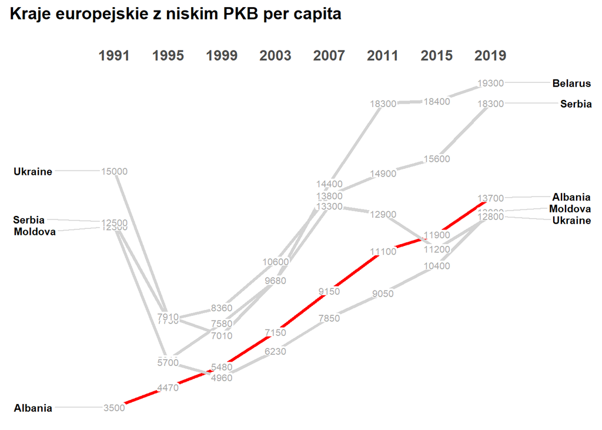

```r
dane %>%
  mutate(rok = as.factor(year),
         PKB = income) %>%
  filter(country %in% c("Albania", "Belarus",
                        "Moldova", "Serbia", "Ukraine"),
         rok %in% c(seq(1991, 2019, 4))) %>%
  select(rok, kraj = country, PKB) %>%
  as.data.frame() %>%
  newggslopegraph(
    Times = rok,
    Measurement = PKB,
    Grouping = kraj,
    Title = "Kraje europejskie z niskim PKB per capita",
    SubTitle = "",
    Caption = NULL,
    LineThickness = 1.25,
    LineColor = c("red", rep("lightgrey", 5)),
    DataTextSize = 2.75,
    DataTextColor = "darkgrey"
  )
```

#### Zajmijmy się gospodarką.

### **ROLNICTWO**

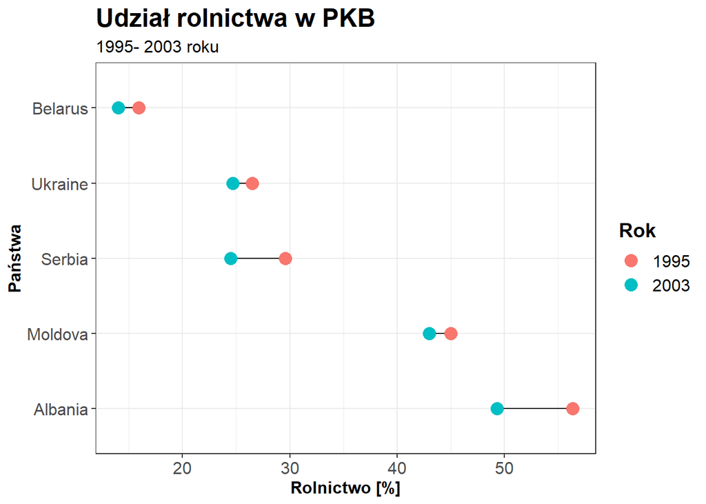

```r
dane %>%
  filter(
    year %in% c(1995, 2003),
    country %in% c("Albania", "Belarus",
                   "Moldova", "Serbia", "Ukraine")
  ) %>%
  ggplot(aes(x = agriculture, y = reorder(country, -agriculture))) +
  geom_line() +
  geom_point(aes(color = year), size = 4) +
  theme(legend.position = "right") +
  labs(
    title = "Udział rolnictwa w PKB",
    subtitle = "1995- 2003 roku",
    x = "Rolnictwo [%]",
    y = "Państwa",
    color = "Rok"
  ) +
  theme_bw() +
  theme(
    axis.text = element_text(size = 12),
    axis.title = element_text(size = 12,
                              face = "bold"),
    plot.title = element_text(size = 18,
                              face = "bold"),
    plot.subtitle = element_text(size = 12),
    legend.title = element_text(size = 14,
                                face = "bold"),
    legend.text = element_text(size = 12)
  )
```

#### Wszystkie państwa zanotowały spadek udziału rolnictwa w PKB

### **PRZEMYSŁ**

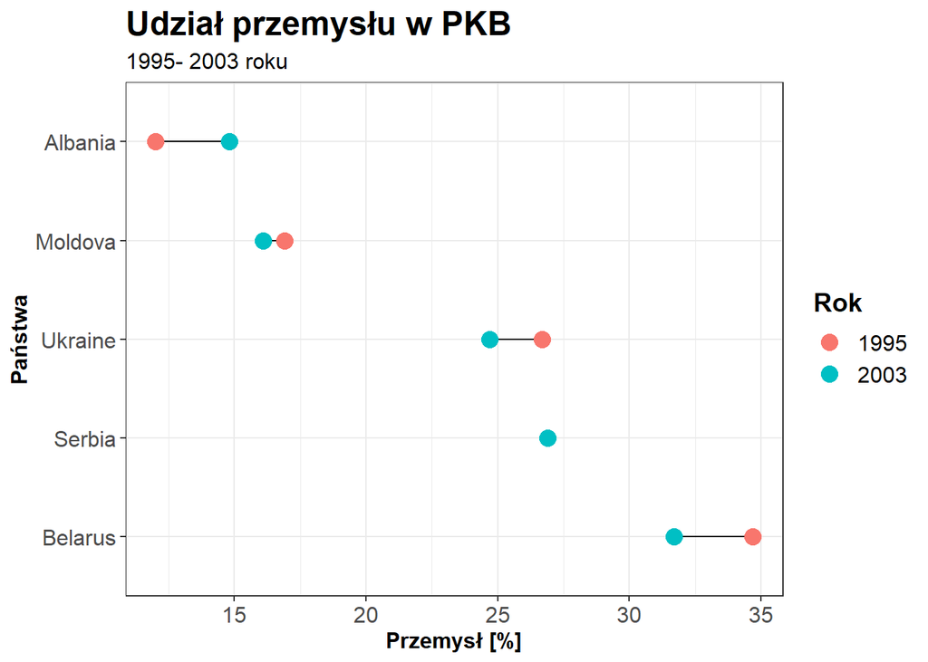

```r
dane %>%
  filter(
    year %in% c(1995, 2003),
    country %in% c("Albania", "Belarus",
                   "Moldova", "Serbia", "Ukraine")
  ) %>%
  ggplot(aes(x = industry, y = reorder(country,-industry))) +
  geom_line() +
  geom_point(aes(color = year), size = 4) +
  theme(legend.position = "right") +
  labs(
    title = "Udział przemysłu w PKB",
    subtitle = "1995- 2003 roku",
    x = "Przemysł [%]",
    y = "Państwa",
    color = "Rok"
  ) +
  theme_bw() +
  theme(
    axis.text = element_text(size = 12),
    axis.title = element_text(size = 12,
                              face = "bold"),
    plot.title = element_text(size = 18,
                              face = "bold"),
    plot.subtitle = element_text(size = 12),
    legend.title = element_text(size = 14,
                                face = "bold"),
    legend.text = element_text(size = 12)
  )
```

### **USŁUGI**

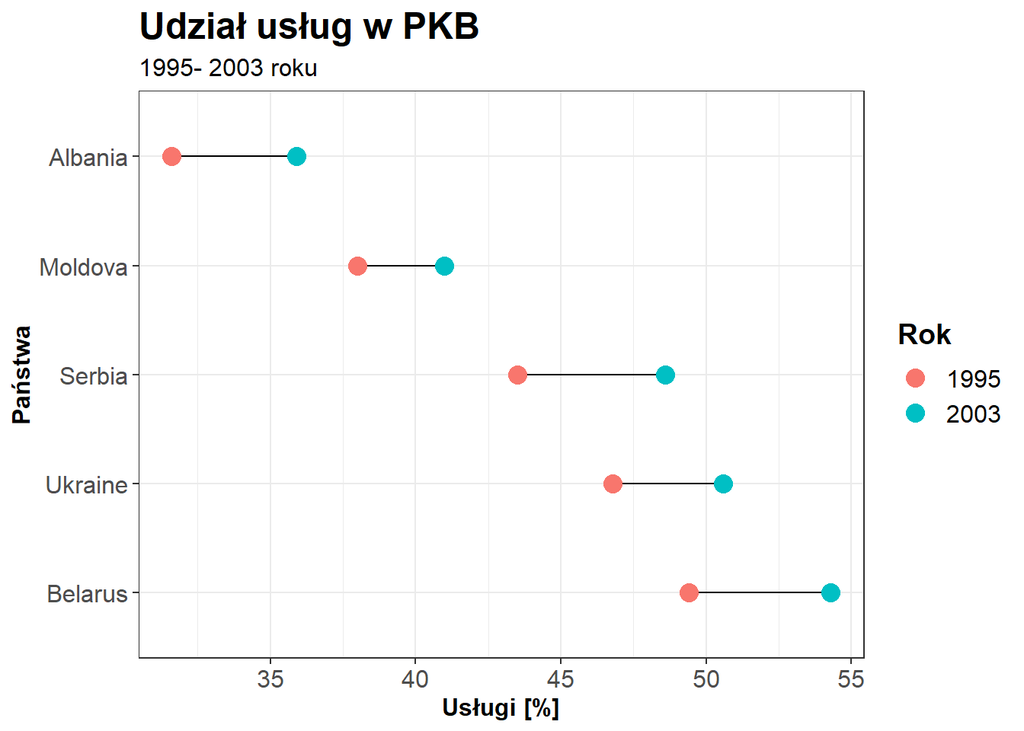

```r
dane %>%
  filter(
    year %in% c(1995, 2003),
    country %in% c("Albania", "Belarus",
                   "Moldova", "Serbia", "Ukraine")
  ) %>%
  ggplot(aes(x = services, y = reorder(country,-services))) +
  geom_line() +
  geom_point(aes(color = year), size = 4) +
  theme(legend.position = "right") +
  labs(
    title = "Udział usług w PKB",
    subtitle = "1995- 2003 roku",
    x = "Usługi [%]",
    y = "Państwa",
    color = "Rok"
  ) +
  theme_bw() +
  theme(
    axis.text = element_text(size = 12),
    axis.title = element_text(size = 12,
                              face = "bold"),
    plot.title = element_text(size = 18,
                              face = "bold"),
    plot.subtitle = element_text(size = 12),
    legend.title = element_text(size = 14,
                                face = "bold"),
    legend.text = element_text(size = 12)
  )
```

#### Wszystkie państwa zwiększyły udział usług w PKB.

# **4. Czy HDI w analizowanych państwach europejskich o niskim PKB per capita wykazywało większą dynamikę zmian niż rozwinięte kraje europejskie?**

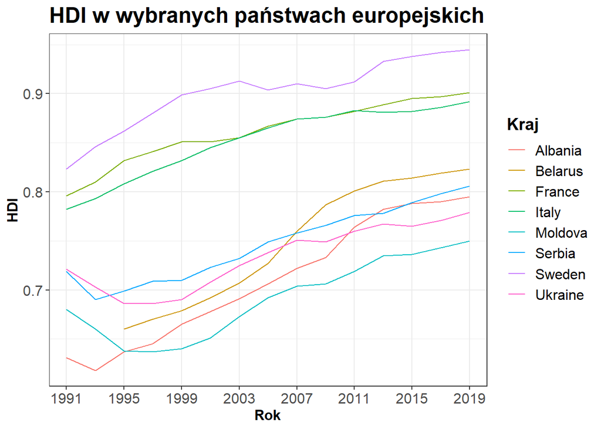

#### Wskaźnik HDI ma większe wartości przez cały badany okres dla państw rozwiniętych.

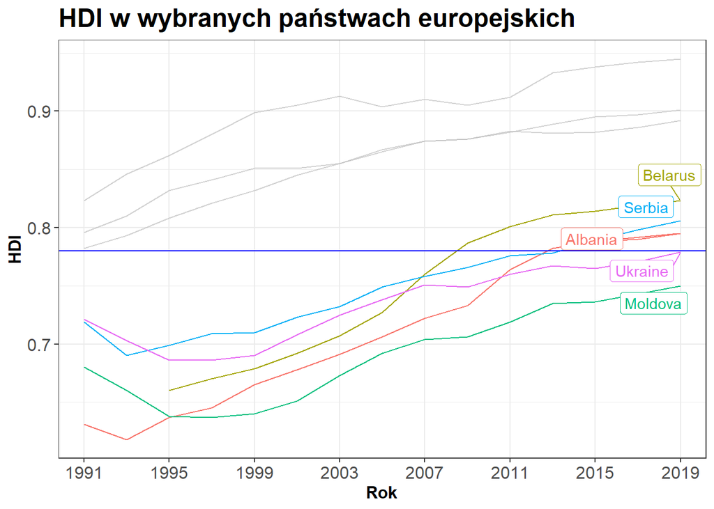

```r
dane %>%
  filter(
    country %in% c(
      "Albania",
      "Belarus",
      "Moldova",
      "Serbia",
      "Ukraine",
      "Italy",
      "France",
      "Sweden"
    )
  ) %>%
  ggplot(aes(
    x = year,
    y = hdi,
    group = country,
    col = country
  )) +
  labs(
    title = "HDI w wybranych państwach europejskich",
    x = "Rok",
    y = "HDI",
    color = "Kraj"
  )+
  geom_line() +
  scale_x_discrete(breaks = seq(1991, 2019, 4)) +
  theme_bw() +
  theme(
    axis.text = element_text(size = 12),
    axis.title = element_text(size = 12,
                              face = "bold"),
    plot.title = element_text(size = 18,
                              face = "bold"),
    legend.title = element_text(size = 14,
                                face = "bold"),
    legend.text = element_text(size = 12)
  ) + gghighlight(country %in% c("Albania",
      "Belarus",
      "Moldova",
      "Serbia",
      "Ukraine"), label_key = country)+
 geom_abline(slope = 0,
              intercept = 0.78,
              color = "blue")
```

#### Na kolejnym wykresie znajduje się linia przedstawiająca początkowy poziom wskaźnika HDI w krajach rozwiniętych. Państwa z niższym PKB per capita (są to linie kolorowe) po 20 latach znalazły się na podobnym poziomie.

#### Zbadajmy wskaźnik dynamiki HDI wybranych państw.

#### Jest to iloraz wielkości wskaźnika HDI danego obszaru w roku końcowym i wielkości wskaźnika HDI tego obszaru w roku początkowym pomnożony przez 100. Pokażę obliczenie na jednym przykładzie, reszta działa analogicznie.

#### Albania:

```r
Albania0 <-as.numeric( dane %>%
  filter(country == "Albania",year == 1991 )%>%
  select(hdi))

Albania1 <- as.numeric(dane %>%
  filter(country == "Albania",year == 2019 )%>%
  select(hdi))

(alb<-(Albania1/Albania0)*100)
```

```
## [1] 125.9905
```

#### Białoruś:

```
## [1] 124.697
```

#### Mołdawia:

```
## [1] 110.2941
```

#### Serbia:

```
## [1] 112.1001
```

#### Ukraina:

```
## [1] 108.0444
```

#### Włochy:

```
## [1] 114.0665
```

#### Francja:

```
## [1] 113.191
```

#### Szwecja:

```
## [1] 114.8238
```

```r
mean(alb, ukr,ser,bel,mol)
```

```
## [1] 125.9905
```

```r
mean(fra,itl,swe)
```

```
## [1] 113.191
```

#### Zatem można stwierdzić, że **HDI w analizowanych państwach europejskich o niskim PKB per capita wykazywało większą dynamikę zmian niż rozwinięte kraje europejskie**

# **5. Czy w państwach z wyższym wskaźnikiem urbanizacji większość jest zatrudniona w usługach ?**

#### Aby zbadać tą hipotezę przyjmijmy, że wysoki wskaźnik urbanizacji występuje powyżej 75%

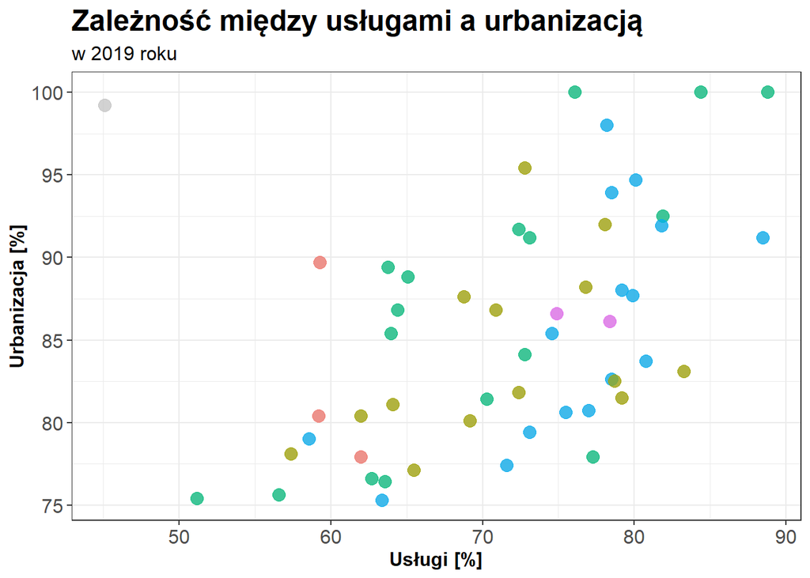

```r
dane %>%
  filter(year == 2019, urban > 75) %>%
  select(country, year, services, urban, continent) %>%
  ggplot() +
  geom_point(
    mapping = aes(x = services, y = urban, col = continent),
    size = 3.5,
    alpha = 0.7
  ) +
  labs(
    title = "Zależność między usługami a urbanizacją",
    subtitle = "w 2019 roku",
    x = "Usługi [%]",
    y = "Urbanizacja [%]",
    color = "Kontynent"
  ) +
  theme_bw() +
  theme(
    axis.text = element_text(size = 12),
    axis.title = element_text(size = 12,
                              face = "bold"),
    plot.title = element_text(size = 18,
                              face = "bold"),
    plot.subtitle = element_text(size = 12),
    legend.title = element_text(size = 14,
                                face = "bold"),
    legend.text = element_text(size = 12)
  ) + gghighlight(services > 50, label_key = country)
```

Zatem można stwierdzić, że **w państwach z wyższym wskaźnikiem urbanizacji większość jest zatrudniona w usługach**

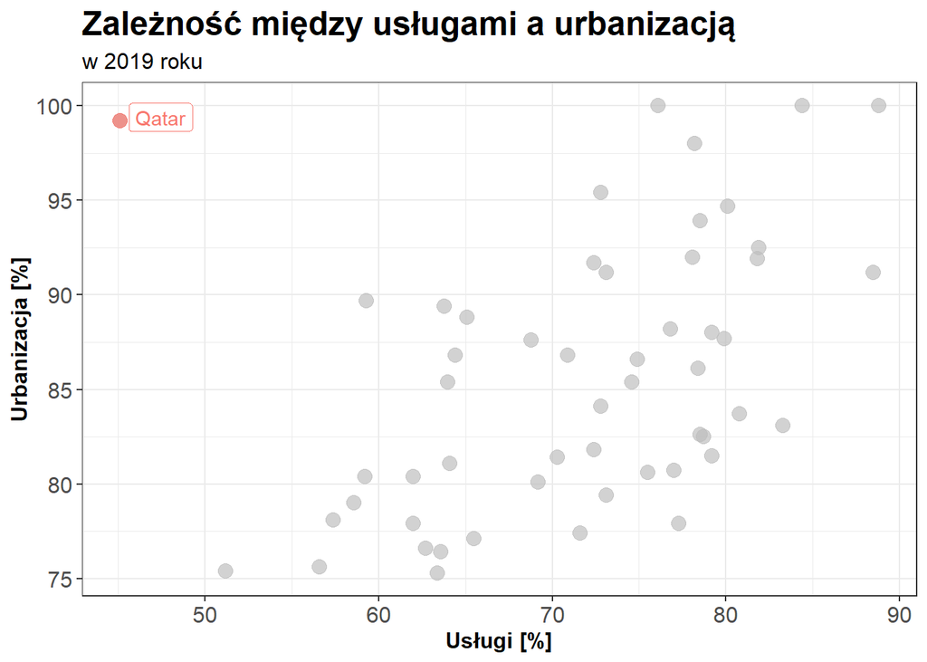

#### Jedynym państwem, które nie potwierdza mojej hipotezy jest Katar.

# **6. Czy w państwach z większą śmiertelnością dzieci większość PKB wytwarzana jest w rolnictwie ?**

#### Sprawdźmy w jakich państwach występuje największa śmiertelność dzieci.

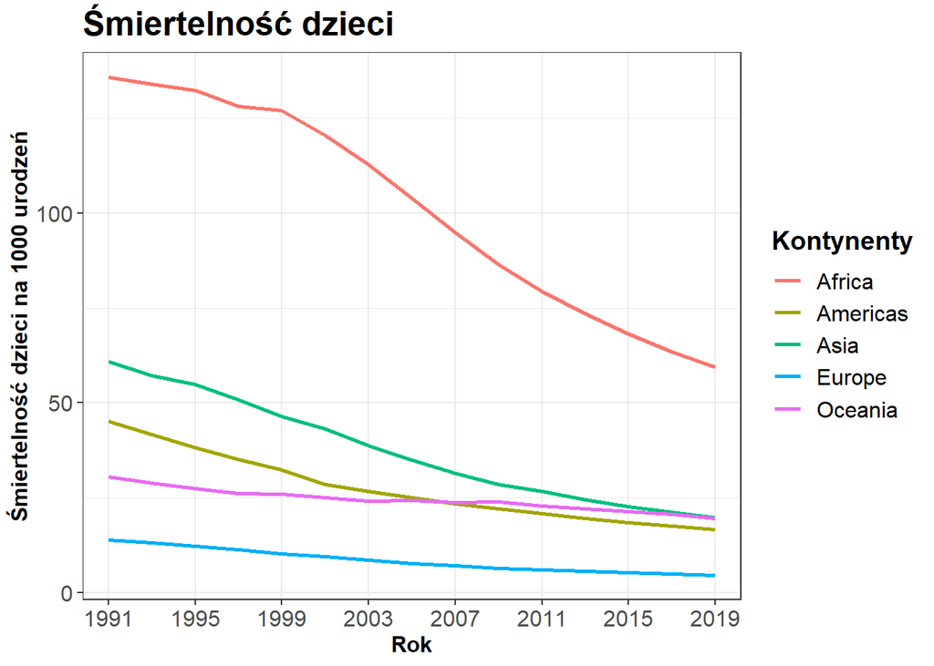

```r
dane %>%
  select(country, year, continent, children) %>%
  group_by(continent, year) %>%
  summarise(inc = mean(children)) %>%
  ggplot(aes(
    x = year,
    y = inc,
    col = continent,
    group = continent
  )) +
  geom_line(size=1) +
  scale_x_discrete(breaks = seq(1991, 2019, 4)) +
  labs(
    title = "Śmiertelność dzieci",
    x = "Rok",
    y = "Śmiertelność dzieci na 1000 urodzeń",
    color = "Kontynenty"
  ) +
  theme_bw() +
  theme(
    axis.text = element_text(size = 12),
    axis.title = element_text(size = 12,
                              face = "bold"),
    plot.title = element_text(size = 18,
                              face = "bold"),
    legend.title = element_text(size = 14,
                                face = "bold"),
    legend.text = element_text(size = 12)
  )
```

```r
(dane%>%
  filter(children>60) %>%
   select(country,year,continent,agriculture))
```

```
## # A tibble: 692 × 4
##    country     year  continent agriculture
##    <chr>       <chr> <fct>           <dbl>
##  1 Afghanistan 1991  Asia             63.4
##  2 Afghanistan 1993  Asia             64.4
##  3 Afghanistan 1995  Asia             64.3
##  4 Afghanistan 1997  Asia             65
##  5 Afghanistan 1999  Asia             65.5
##  6 Afghanistan 2001  Asia             66.3
##  7 Afghanistan 2003  Asia             63.7
##  8 Afghanistan 2005  Asia             62.1
##  9 Afghanistan 2007  Asia             60.1
## 10 Afghanistan 2009  Asia             56.9
## # … with 682 more rows
```

[figure not shown]

```r
dane %>%
  filter(year == 2007,
    country %in% c(
      "Afghanistan",
      "Azerbaijan",
      "Burundi",
      "Bangladesh",
      "Bolivia",
      "Cameroon",
      "Ghana",
      "India"
    )
  ) %>%
  ggplot(aes(x = children, y = agriculture, col = country)) +
  geom_point(size = 2) +
  labs(
    title = "Rolnictwo a śmiertelność dzieci",
    subtitle = "w 1991",
    x = "Śmiertelność dzieci na 1000 urodzeń",
    y = "Rolnictwo [%]",
    color = "Kraj"
  ) +
  theme_bw() +
  theme(
    axis.text = element_text(size = 12),
    axis.title = element_text(size = 12,
                              face = "bold"),
    plot.title = element_text(size = 18,
                              face = "bold"),
    plot.subtitle = element_text(size=12),
    legend.title = element_text(size = 14,
                                face = "bold"),
    legend.text = element_text(size = 12)
  )+gghighlight(agriculture>=50)
```

#### Im większy jest udział rolnictwa w PKB tym większa jest liczba śmierci dzieci na 1000 urodzeń. Zatem można stwierdzić, że **w państwach z większą śmiertelnością dzieci większość PKB wytwarzana jest w rolnictwie**

# 7. **Czy praca fizyczna ma wpływ na długość życia?**

#### Praca fizyczna oznacza pracę w rolnictwie.

[figure not shown]

```r
dane %>%
  filter(year == 1991) %>%
  ggplot() +
  geom_point(
    mapping = aes(x = lifExp,
                  y = agriculture),
    color = "red",
    alpha = 0.5,
    size = 2
  ) +
  labs(title = "Rolnictwo a długość życia",
       subtitle = "w 2007 roku",
       x = "Długość życia",
       y = "Rolnictwo [%]", )+
  theme_bw() +
  theme(
    axis.text = element_text(size = 12),
    axis.title = element_text(size = 12,
                              face = "bold"),
    plot.subtitle = element_text(size = 12),
    plot.title = element_text(size = 18,
                              face = "bold"),
    legend.title = element_text(size = 14,
                                face = "bold"),
    legend.text = element_text(size = 12)
  )
```

#### Na wykresie można zauważyć, że gdy rośnie oczekiwana długość życia maleje udział rolnictwa w PKB. Dla pewności sprawdźmy jeszcze, ile wynosi korelacja między tymi danymi.

```r
cor(dane$agriculture,dane$lifExp,)
```

```
## [1] -0.7870309
```

#### Korelacja jest dość silna. Można więc uznać, że **praca fizyczna ma wpływ na długość życia**

# **8. Jak zmieniła się przeciętna śmiertelności dzieci?**

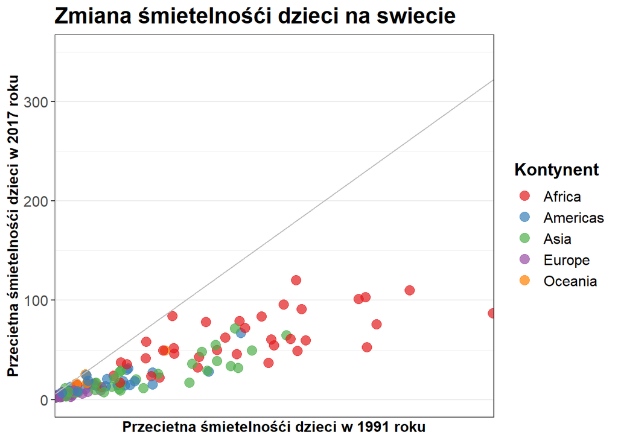

```r
dane %>%
  filter(year %in% c(1991, 2017)) %>%
  select(country, year, children, continent) %>%
  spread(year, children) %>%
  rename(sm_dz_1991 = "1991",
        sm_dz_2007 = "2017") %>%
  ggplot() +
  geom_point(
    mapping = aes(x = sm_dz_1991, y = sm_dz_2007, col = continent),
    size = 3.5,
    alpha = 0.7
  ) +
  geom_abline(slope = 1,
              intercept = 0,
              color = "grey") +
  labs(
    title = "Zmiana śmietelnośći dzieci na swiecie",
    x = "Przecietna śmietelnośći dzieci w 1991 roku",
    y = "Przecietna śmietelnośći dzieci w 2017 roku",
    color = "Kontynent"
  ) +
  ylim(0, 350) +
  xlim(0, 350) +
  scale_color_brewer(palette = "Set1") +
  scale_x_discrete(breaks = seq(1991, 2019, 4)) +
  theme_bw() +
  theme(
    axis.text = element_text(size = 12),
    axis.title = element_text(size = 12,
                              face = "bold"),
    plot.title = element_text(size = 18,
                              face = "bold"),
    legend.title = element_text(size = 14,
                                face = "bold"),
    legend.text = element_text(size = 12)
  )
```

#### **Przeciętna liczba śmierci dzieci na 1000 urodzeń w przeciągu lat zmalała.**